# Weekly Indicators

Fishing season 2022

[figure not shown]

```r
# define paths
#base.dir <- 'https://github.com/khyde/SquidSquad.git'
base.dir <- 'C:/Users/sarah.salois/Desktop/github/khyde/SquidSquad/'
base.url <- '/'
fig.path <- 'images/'

# this is where figures will be sent
paste0(base.dir, fig.path)

# this is where markdown will point for figures
paste0(base.url, fig.path)


#knitr::include_graphics('C:/Users/sarah.salois/Documents/github/khyde/SquidSquad/images/SquidSquadV1.png')
# p5 <- ggdraw() + draw_image('C:/Users/sarah.salois/Documents/github/khyde/SquidSquad/images/SquidSquadV1.png', scale = 0.5)
# plot_grid(p5)


# <div style="display: flex;">
```

> Weekly updates for oceanographic indicators for the Northern Shortfin Squid, *Illex illecebrosus*.

This page is aimed to provide near-real-time observations of relevant oceanographic conditions in the Northwest Atlantic to aid in our understanding of the patterns of availability of *Illex*. This page will be updated weekly and weekly observations will be retained and accessible via the table of contents in the upper left hand corner of this page. ***

# May

> Oceanographic conditions for the month of May 2022

```r
# This bit is an updated way to add in .png's, hopefully use to automate
# Need to decide on naming scheme and folder allocation
rundate <- "0505"
# or maybe we could pull from weekly folder 'runweek'
# here::here("images/desired.png") # gets path
# here::here("images/chl/chl_0505.png") # gets path
#knitr::include_graphics(here::here("images/chl/chl_0505.png"))
knitr::include_graphics(here::here(paste0("images/chl/chl_", rundate, ".png")))
# Another way to include images
```

## Week 19 (May 8 - May 14)

**JCC May 09, 2022**

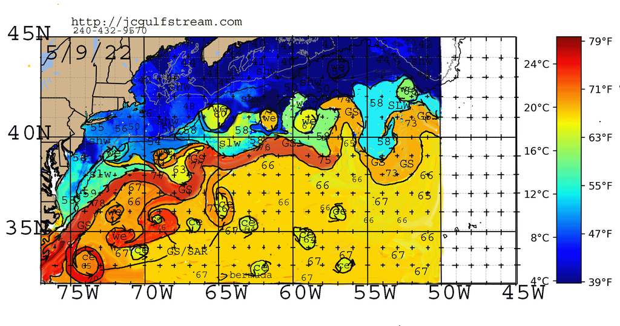

**JCC May 11, 2022**

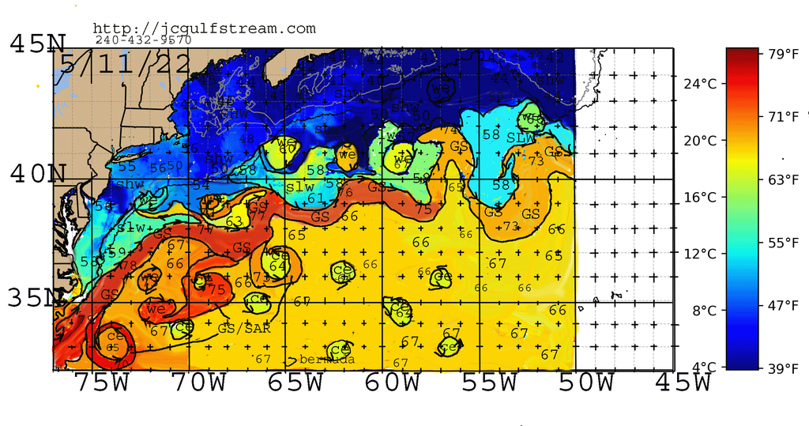

AG: Two WCRs in our region – both connected to the Gulf Stream with individual Squid bridges or streamers. ***

## Week 18 (May 1-7)

**Chlorophyll**

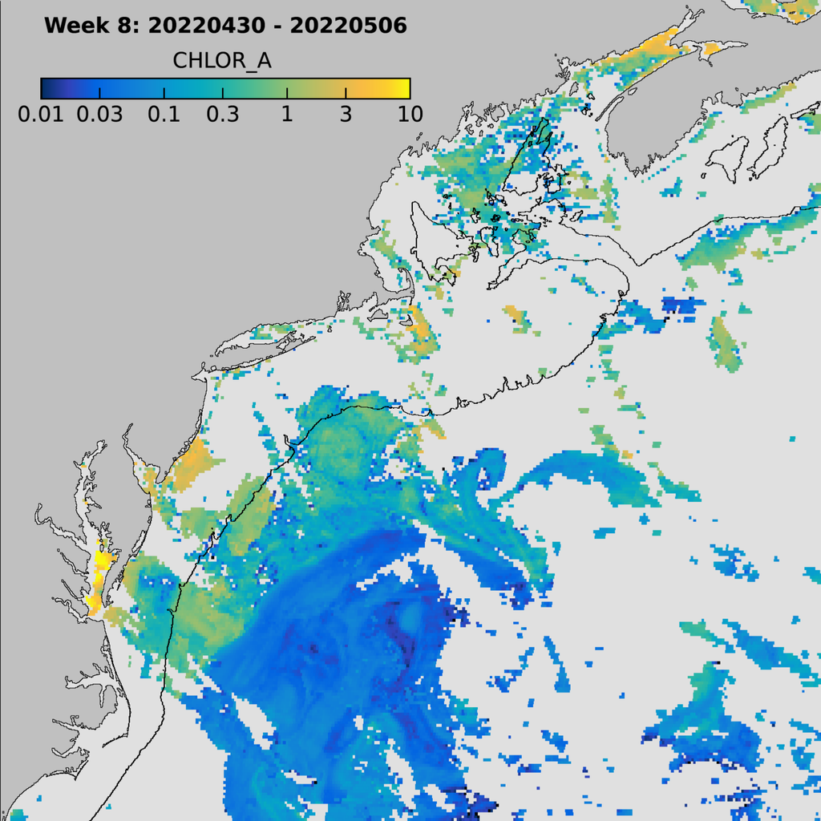

**JCC May 04, 2022**

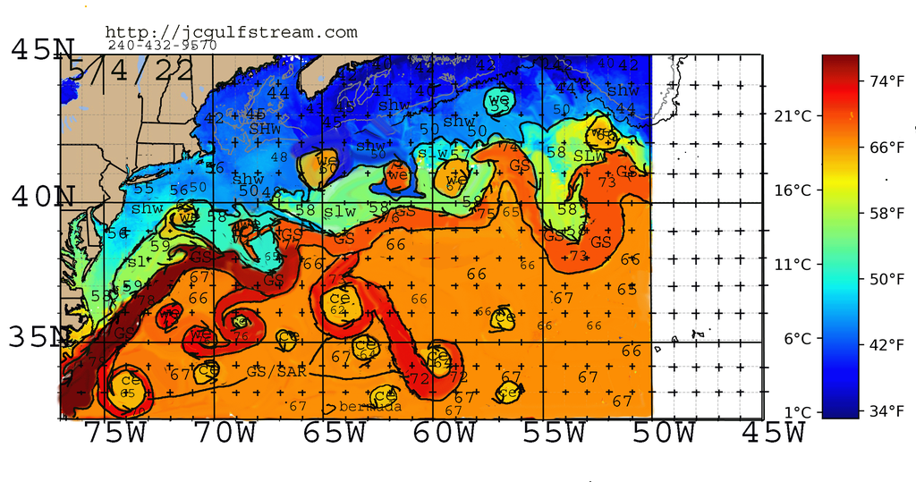

**JCC May 06, 2022**

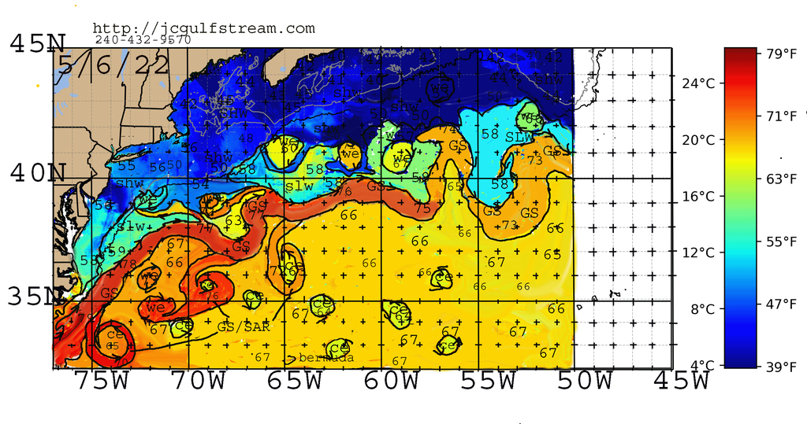

**Mean Salinity (Pioneer Array, CENTRAL)**

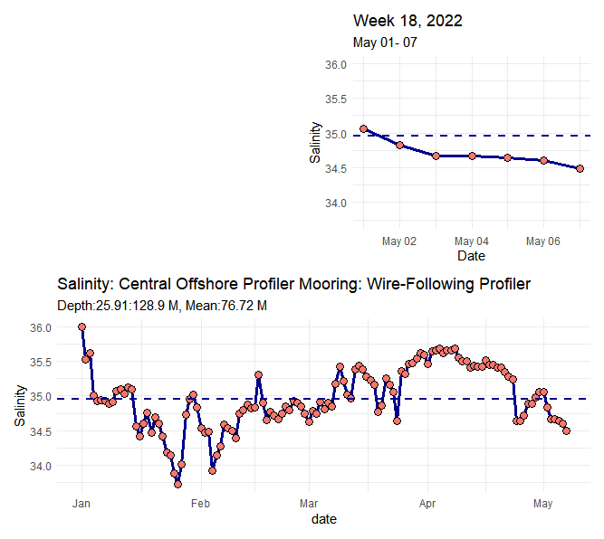

**Mean Salinity (Pioneer Array, INSHORE)**

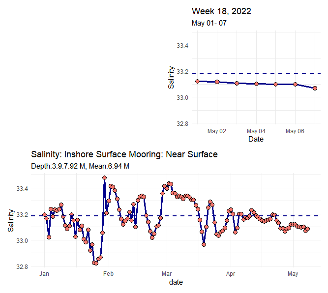

**Mean Salinity (Pioneer Array, OFFSHORE)**

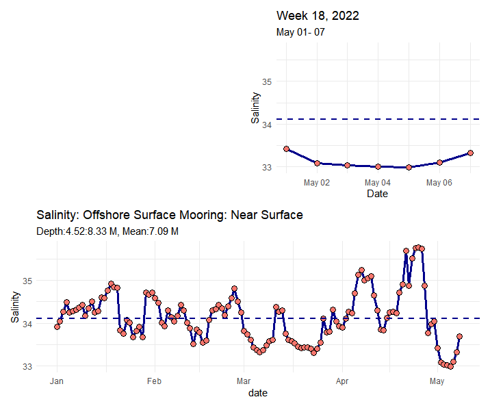

**YTD : Mean Salinity (Pioneer Array, w/2021 reference)**

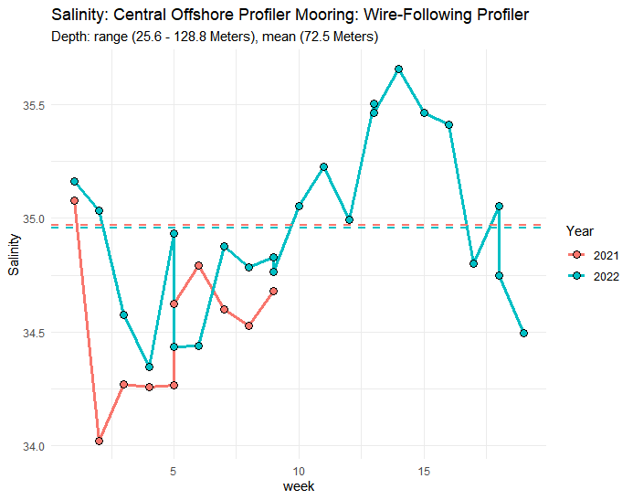

```r
# Trial run :
# This works in chunk but wont knit **
jc_weekly <- list.files(here::here('images/jc_charts'),
                        pattern = '.png',
                        full.names = TRUE)
knitr::include_graphics(jc_weekly)
```

```r
# This works in chunk but wont knit **

knitr::include_graphics(here::here(c("images/jc_charts/jc_0425.jpg", 'images/jc_charts/jc_0427.jpg')))
```

## Week 17 (April 24 - April 30)

**Chlorophyll**

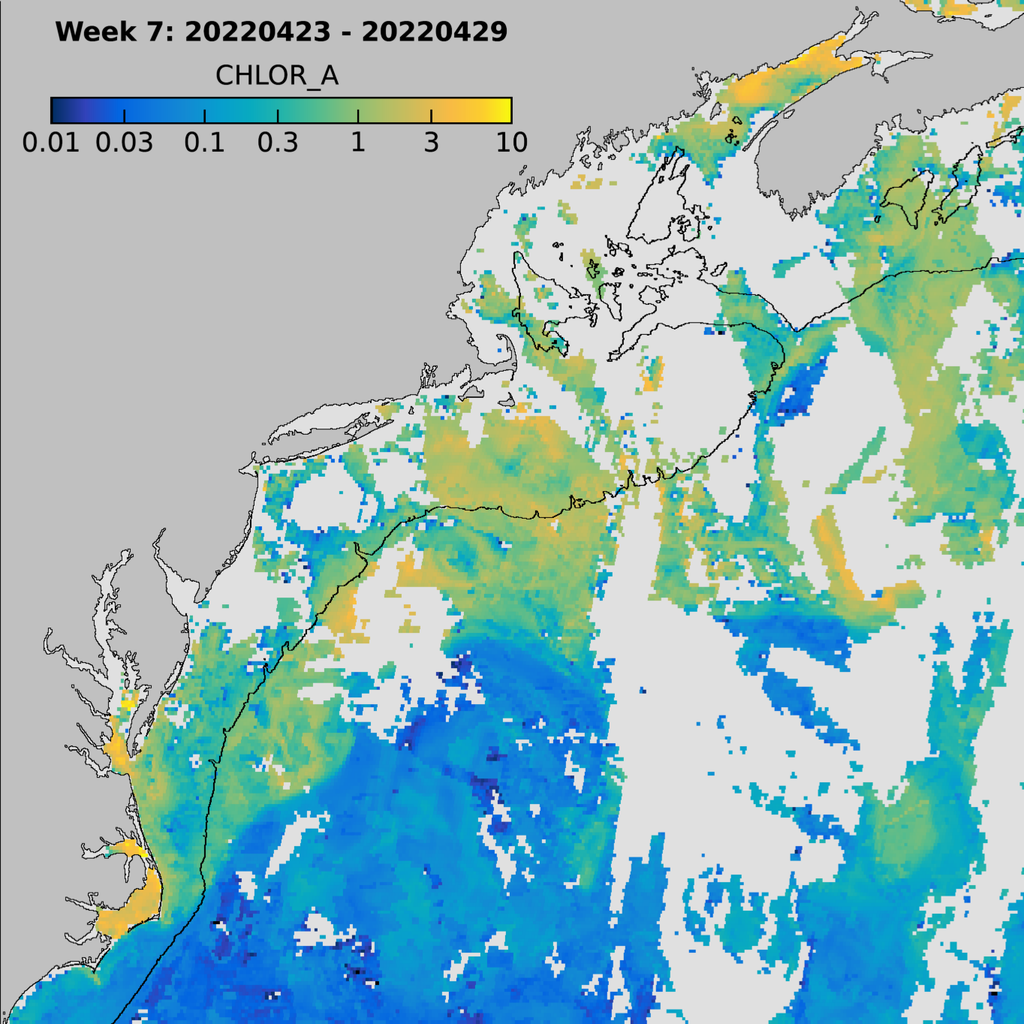

**JCC April 25, 2022**

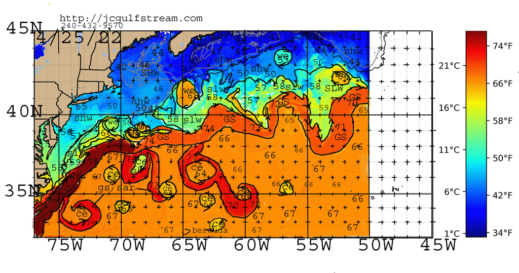

**JCC April 27, 2022**

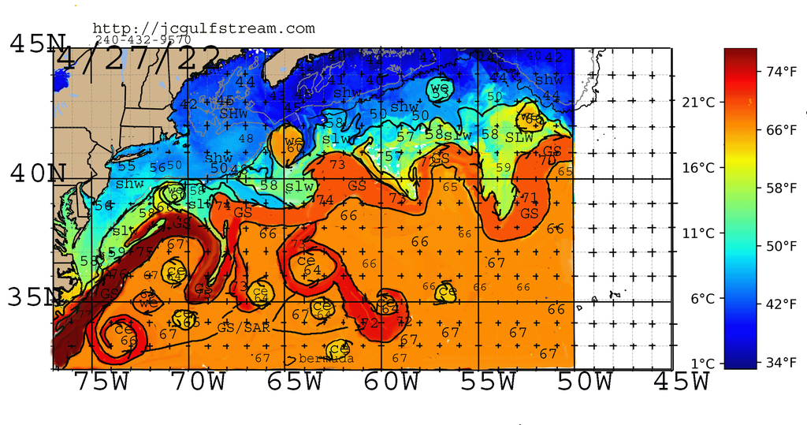

# April

## Week 16 (April 17 - April 23)

**Chlorophyll**

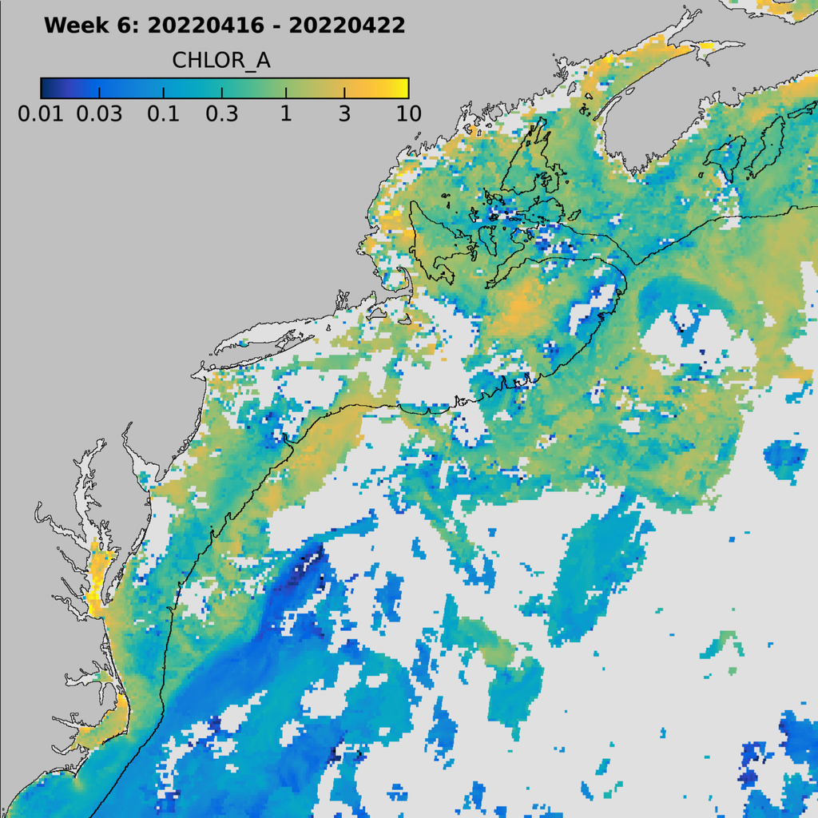

## Week 15 (April 10 - April 16)

**JCC April 11, 2022**

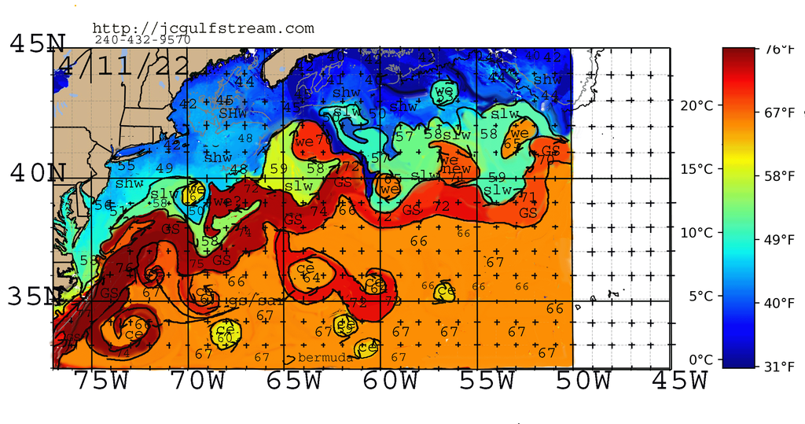

**JCC April 13, 2022**

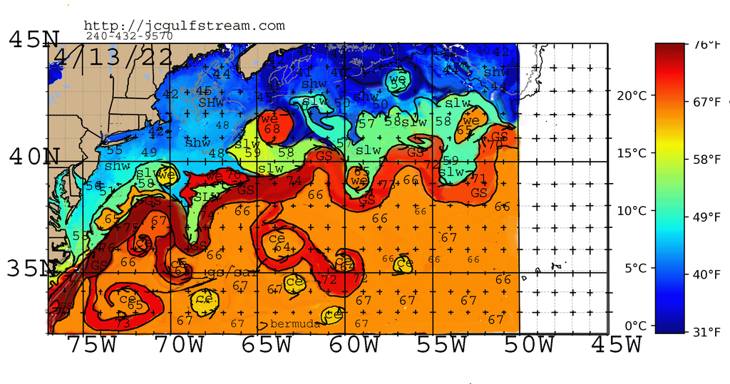

AG: Things are heating up with really warm GS water closing in on the shelf break near 67W!

- 4/11: As Adrienne predicted last week, there might be a ring forming near 67W! And look at the temperature difference between the ring water (72F) and the shelf water (48F) next to each other!
- 4/13: The Gulf Stream has a mind of its own! Look at the huge trough near 69-70W now!

GG: Some remarkable processes revealed in this image, including a possible squid bridge to the shelfbreak.

AM: Lots going on out there to keep track of as we inch closer to squid season. No signs of squid yet, other than some large ones in the bellies of tuna offshore

## Week 14 (April 3 - April 9)

**JCC April 06, 2022**

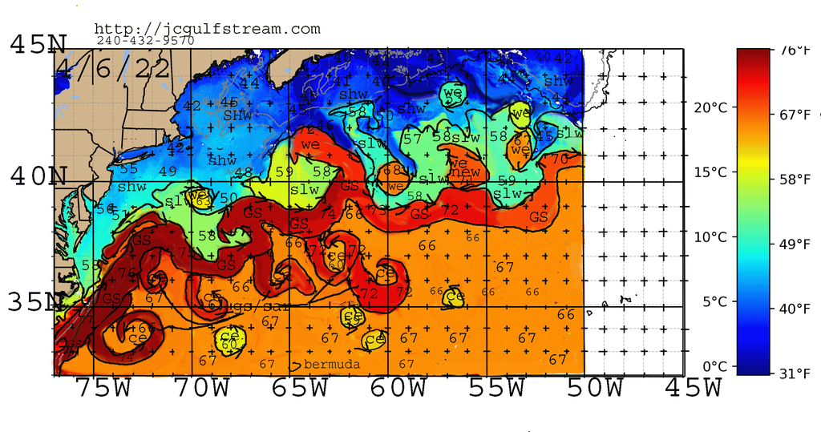

**JCC April 08, 2022**

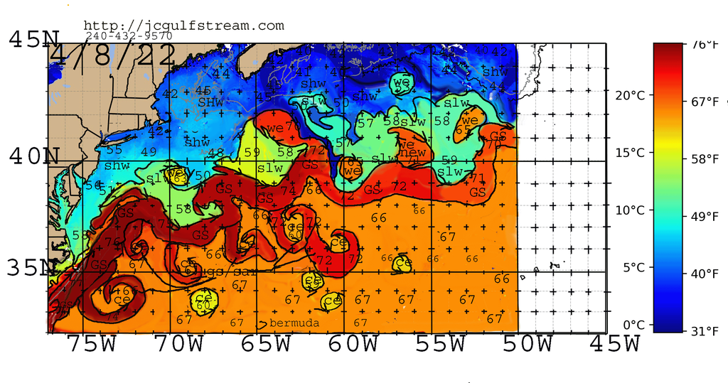

AG: (4/6/22) There is one WCR on the shelf break and a large streamer along the MAB shelf. A lot of activity to the east of the Ring-meander set up at 65W.

- Magdalena who just came back visiting the NESC, notes the water is warm out there

AG: (4/8/22) WCR forming at 62-64W and the nice shelf-streamers to just east of it and then down along the GS crest’s leading edge.

- This shelf water (blue band) is also going to interact with the WCR at 60W in the coming week!

**April Salinity Time Series (Pioneer Array, *in-situ* data)**

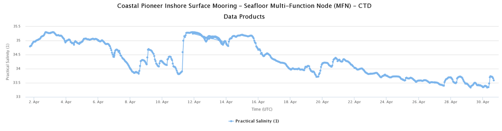

# General Information

## Major Canyons

Major Canyons

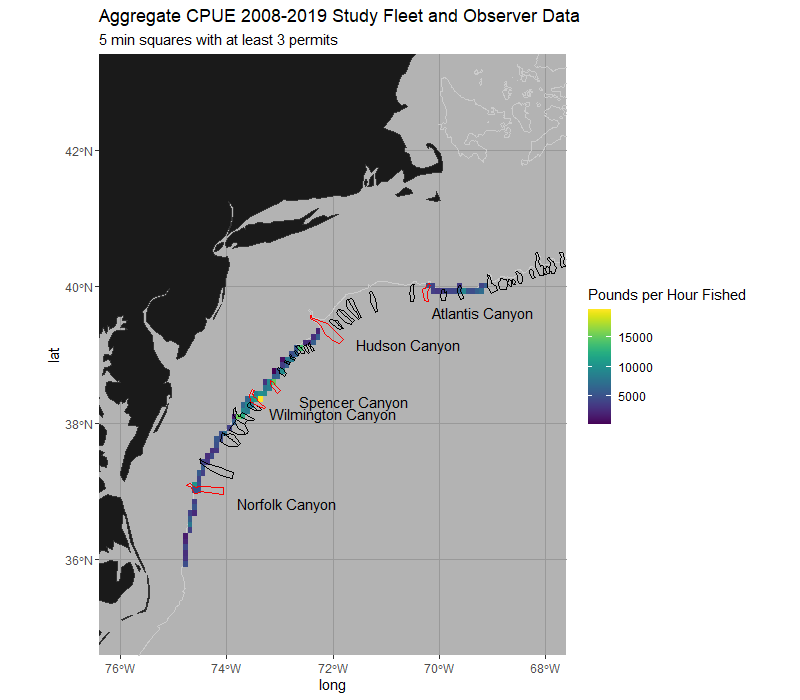

```r
#
```

## Body weight trends across years

A quick look at the average body weight data from 1997 through 2019. The data were derived via subsamples collected from landings from various Illex processors. Colors correspond to Paul Rago’s qualitative measures of system state, where green indicates a ‘Good’ year, pink an ‘Average’ year and blue a ‘Poor’ year.

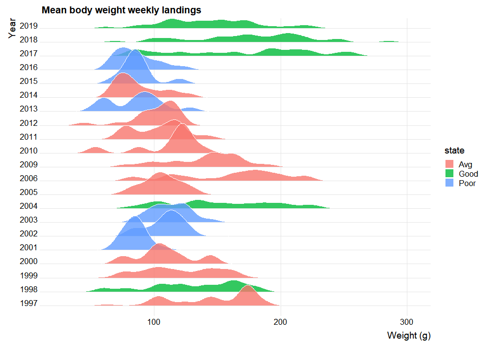

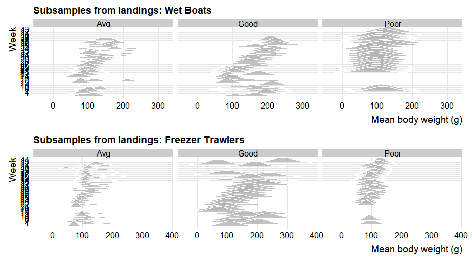

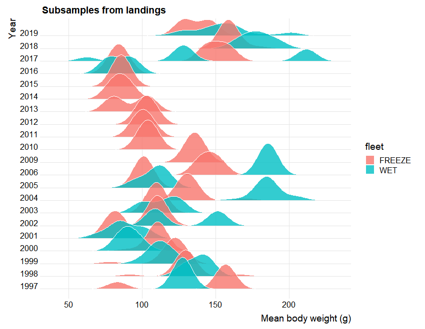

## Fishing depths 2021 Fishing Season

The figure below highlights the 100 meter isobath and associated fishing depths throughout the 2021 season.

[figure not shown]

## NAFO subareas

This shape file depicts a range of 20 meters inshore of the shelf break (200m isobath)

```r
library(mapdata) # dist2isobath
library(marmap)  # getNOAA.bathy
## bring in bathymetry data from marmap package
pt.baty415 <- getNOAA.bathy(lon1 = -66, lon2 = -76,
                            lat1 = 35, lat2 = 44,
                            resolution = 1) #41.5
## get coastline from mapdata
reg = map_data("world2Hires")
reg = subset(reg, region %in% c('Canada', 'USA', 'Mexico'))
reg$long = (360 - reg$long)*-1
```

```r
wd =  here::here('shapefiles/')
nafo_shbr <- readOGR(wd,'NAFO_SHELFBREAK', verbose = FALSE)
inshr <- nafo_shbr[nafo_shbr@data$SUBAREA %in% c('NAFO_5ZE_INSHORE', 'NAFO_5ZW_INSHORE','NAFO_6A_INSHORE', 'NAFO_6B_INSHORE','NAFO_6C_INSHORE'),]
```

```r
# This chunk will extract data across NAFO_SHELFBREAK to get mean values
# for each subarea

# path = '/nadata/PROJECTS/IDL_PROJECTS/ILLEX_INDICATORS/R_SCRIPTS/SALINITY/RASTERS/WEEKLY'
# bricks <- list.files(path = path,
#                      pattern = glob2rx('b_ww_sal_222m*.tif'),
#                      full.names = TRUE)
# k = 13 # 2020
# btmp <- brick(bricks[k])
# btmp@data@names <- as.numeric(c(1:52))
# tmp2 <- subset(tmp, week == weeks[j])
# rtmp = raster::subset(btmp, which(btmp@data@names == weeks[j]))
# rtmp <- raster('test_inshore.tif')
# sal_222m <-  raster::extract(rtmp, inshr, weights = FALSE,
#                              fun = mean, na.rm = TRUE)
# #sal_222m[1:5]
```

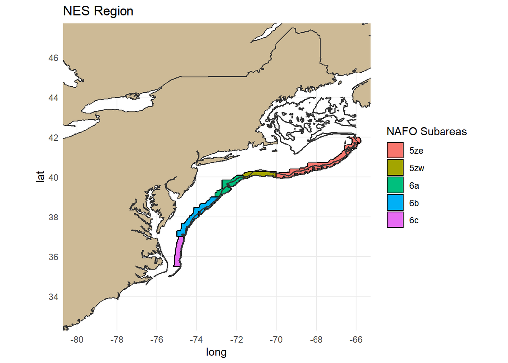

```r
ggplot() +
  geom_polygon(data = reg, aes(x=long, y = lat, group = group),
               color = "gray20", fill = "wheat3") +
  coord_sf(xlim = c(-80,-66), ylim = c(33,47)) +
  geom_polygon(data = inshr, aes(x = long, y = lat,
                                 group = group, fill = id),
               color = 'black') +
  # geom_polygon(data = mjr_canyons, aes(x = long, y = lat,
  #                                      group= group, fill = id),
  #              color = 'black') +
  # scale_fill_discrete(name ='Canyons',
  #                     labels = c('Hudson', 'Wilmington', 'Norfolk')) +
  geom_contour(data = pt.baty415, aes(x = x, y = y, z = z),
               breaks = c(-100,-200), colour ="gray20", size = 0.7) +
  scale_fill_discrete(name ='NAFO Subareas',
                      labels = c('5ze', '5zw', '6a', '6b', '6c'))+

  ggtitle(paste0('NES Region')) +
  theme_minimal()
```

```r
# wd = ('C:/Users/sarah.salois/Documents/github/khyde/SquidSquad')
# canyons <- readOGR(wd, 'major_canyons')
# # reproject data
# # Transform units from UTC (meters) to LatLon (decimal degrees)
# canyons <- spTransform(canyons, CRS('+init=epsg:4326')) # this worked once and now wont
# canyons <- spTransform(canyons,
#                       CRSobj = '+init=epsg:4326 +proj=longlat +datum=WGS84 +no_defs +ellps=WGS84 +towgs84=0,0,0')
# crs(canyons) # check
# extent(canyons) # check
# mjr_canyons <- canyons[canyons@data$Name %in% c('Norfolk Canyon',
#                                                 'Wilmington Canyon',
#                                                 'Hudson Canyon'),]
#
# # different trys to fix projection (longitudes are wrong, extent )
#
# canyons.sf <- st_as_sf(canyons, crs = '+init=epsg:4326 +proj=longlat +datum=WGS84 +no_defs +ellps=WGS84 +towgs84=0,0,0')
# extent(canyons) <- c(-74.34716, -65.91845, 33.74994,37.5575) # was -94.34716,  -85.91845
#
# # Another try
# canyons.sf <- st_set_crs(canyons, "+proj=utm +zone=18 +ellps=GRS80 +datum=NAD83")
# canyons.sf <- st_set_crs(canyons.sf,
#                          '+init=epsg:4326 +proj=longlat +datum=WGS84 +no_defs +ellps=WGS84 +towgs84=0,0,0')
# test.sp <- canyons.sf %>% as("Spatial") # From sf to spatial
# extent(test.sp)
#
# canyons@polygons@coords
# canyons$long = (360 - canyons$long)*-1
# extent(canyons_WGS84)
```

# 2021 Case Study

> JULY 25- 31: Industry noted that squid seemed to have disappeared off the shelf after being present in high abundance for the last few months.

Looking into the oceanographic conditions, team realized there was an increase in sea surface temperature of about 5 degrees over the course of one week. Additionally, they noted continued westward propagation of warm ring/GS water, hypothesized to be dispersing or redistributing the squid.

Below are some figures generated and annotated by Avijit Gangopadhyay and Glen Gawarkiewicz

**JCC: July 23 2021**

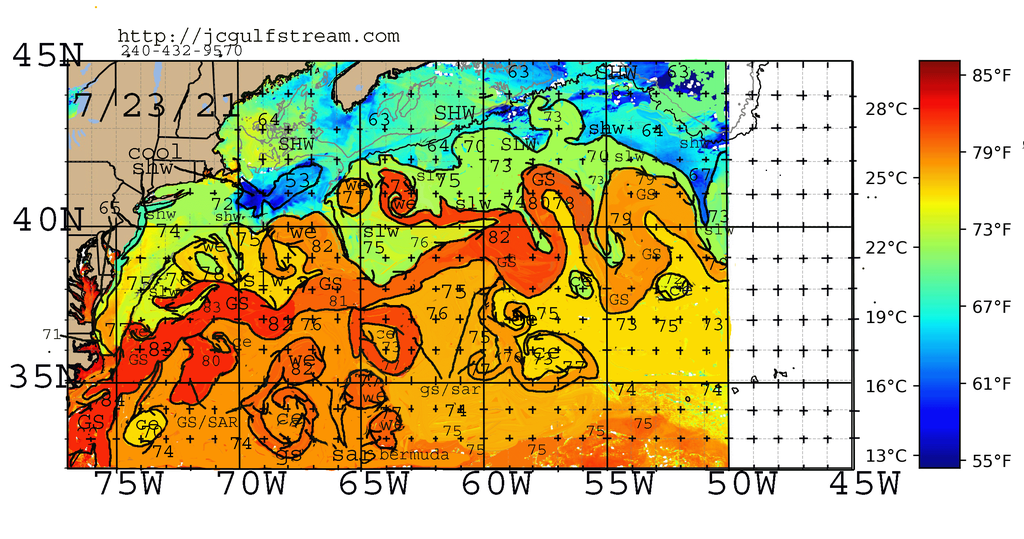

**JCC: July 26 2021**

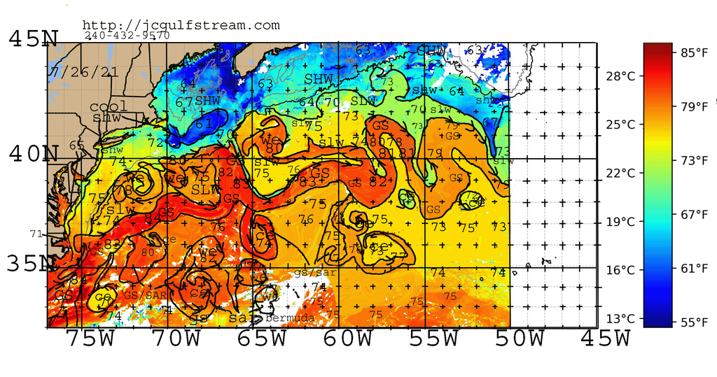

**JCC: August 2 2021**

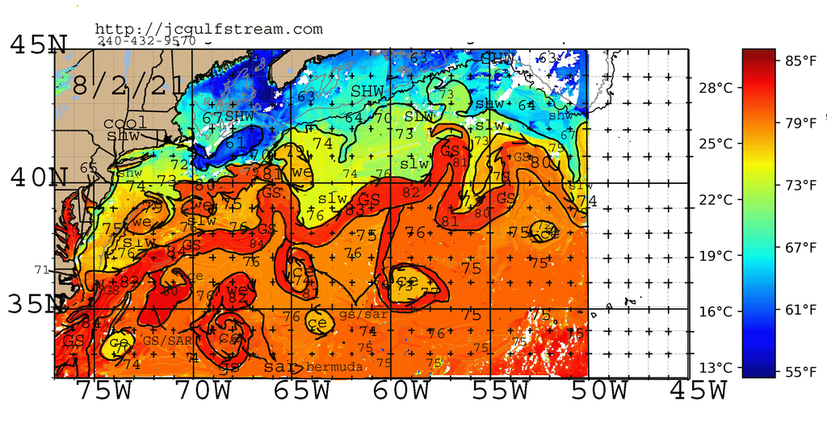

**JCC: August 4 2021**

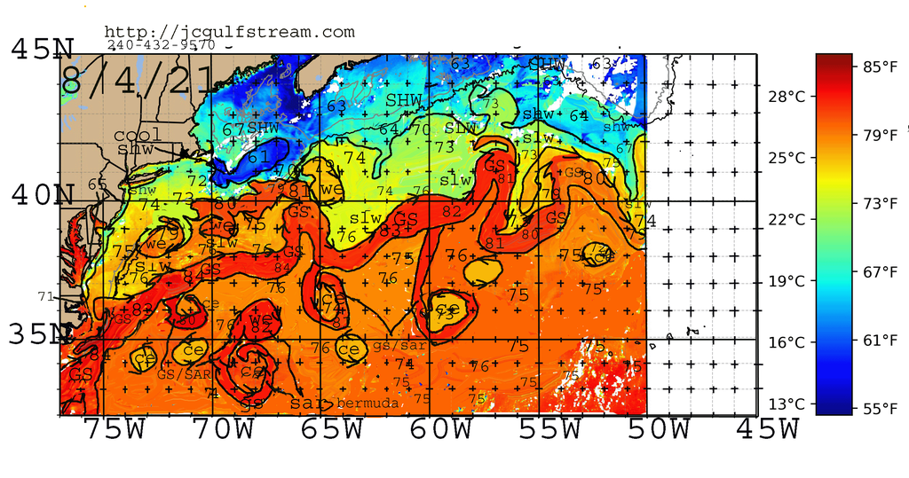

Avijit noted: Temperature along the shelfbreak (from SNE to south of Georges Bank) was about 75F on 7/23/21, increases to about 78-80 on 7/26/21 with mostly westward flow along the shelf break (below Georges Bank) with another WCR covering the SNE shelf (this WCR has colder shelf water in its core – this happened due to the WCR entraining a shelf streamer the previous week). Finally, the whole shelfbreak seems to be warm with temperature at about 79-81 all along SNE and South of the Northeast Channel.

- There is an overall tendency of the warm GS/Ring water flowing westward and flooding the shelfbreak. Is this interacting or part of the shelf break jet itself?
- High temperature all along the shelf break with a train of along-shelf features more like a warm blob. Could it be a new marine heat wave?

**In-situ Salinity time series for the month of July 2021 (from Pioneer Array)**

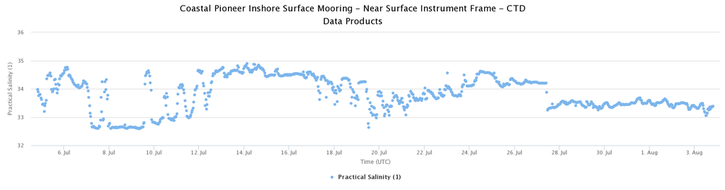

Glen noted: “About a week ago there was a big drop (nearly 1 psu) in salinity at the inshore Pioneer Array mooring at 7 m depth. This is indicative of a big retreat of the slope/ring water. The salinity dropped from around 34.2 to around 33.2 on July 27. Salinities on the outer shelf were very high during the Armstrong cruise the second half of June. The shelf break front was in an anomalously shoreward position, probably 20 NM shoreward of the usual position during the Armstrong cruise June 18-July 2. The shelf break front also was anomalously onshore south of Hudson Canyon recently from Rutgers glider transects. What is interesting over the past 2-3 months is the large number of rings. Ring influence on the outer shelf has been pronounced throughout the entire MAB. I wonder if the front popping back to its normal position has occurred over a large area. We will have to think about ways to test this (altimeter?).”

- This is really important to figure out why a pulse would end as well as why it would begin.

Avijit’s response: “We should look at altimetry. Contours and their movement as well as cross track velocities which will resolve the SBF better. That will tell us a lot. We could also look at winds! And offshore changes might be captured by the few argo floating in these rings. Their trajectories might have changed from a ring-silo configuration to a ring-coalescence configuration.”

> AUGUST 7, 2021 : Industry reports fishing has resumed, starting in a piece of water around Wilmington and Spencers canyon.

JM: The fishing was reportedly not as good as it was a month prior and one harvester reported seeing a change in size frequency of fish available during the last trip from larger to smaller.

```r
jc_img <- system.file('jc_0425.jpg', 'jc0427.jpg', package = "cowplot")
plot_grid(
  p + theme(legend.position = c(1, 1), legend.justification = c(1, 1)),
  p2,
  labels = "AUTO"
)

p1 <- ggdraw() +
  draw_image('C:/Users/sarah.salois/Documents/github/khyde/SquidSquad/images/jc_425_v2.png',
             scale = 0.9)
p2 <- ggdraw() +
  draw_image('C:/Users/sarah.salois/Documents/github/khyde/SquidSquad/images/jc0427.jpg',
             scale = 1.0)
plot_grid(p1, p2)
```

```r
# Would need to play around with image / grid size, not as flexible as columns
p1 <- ggdraw() + draw_image('C:/Users/sarah.salois/Documents/github/khyde/SquidSquad/images/M_201606-MUR-V04.1-NES-SST-STATS-MEAN.png', scale = 1.0)
p2 <- ggdraw() + draw_image('C:/Users/sarah.salois/Documents/github/khyde/SquidSquad/images/M_201603-OCCCI-V5.0-NES-CHLOR_A-CCI-STATS-STD.png', scale = 1.0)
p3 <- ggdraw() + draw_image('C:/Users/sarah.salois/Documents/github/khyde/SquidSquad/images/W_201638-GLORYS-NES-BOTTOM_TEMPERATURE-WCR-CHLFRONTS.png', scale = 1.0)
# p3 <- ggdraw() + draw_image('C:/Users/sarah.salois/Documents/github/khyde/SquidSquad/images/jc0425.jpg', scale = 0.9)

p4 <- ggdraw() + draw_image('C:/Users/sarah.salois/Documents/github/khyde/SquidSquad/images/jc0427.jpg', scale = 1.0)
plot_grid(p1, p2, p3, p4)
```

```r
# Another way to include images
# knitr::include_graphics('C:/Users/sarah.salois/Documents/github/khyde/SquidSquad/images/M_201606-MUR-V04.1-NES-SST-STATS-MEAN.png')
```